# Reto 3: ¿Que maquina elegir ?

## Contexto

Una compañía manufacturera en Cali está considerando la adquisición de una nueva maquinaria para fabricar cajas. Esta decisión es fundamental para mejorar su capacidad de producción y eficiencia en el manejo de materiales. La empresa debe considerar no solo el costo inicial de las máquinas, sino también los costos de mantenimiento anuales y cómo estos costos podrían aumentar con el tiempo debido al desgaste y otros factores económicos.

La depreciación, el impacto en los costos de producción y la contribución a la eficiencia general de los procesos se evalúan además de los costos iniciales y de mantenimiento. Estos son esenciales para tomar una decisión informada que sea tanto económica como estratégica para el crecimiento y la sostenibilidad de la empresa.

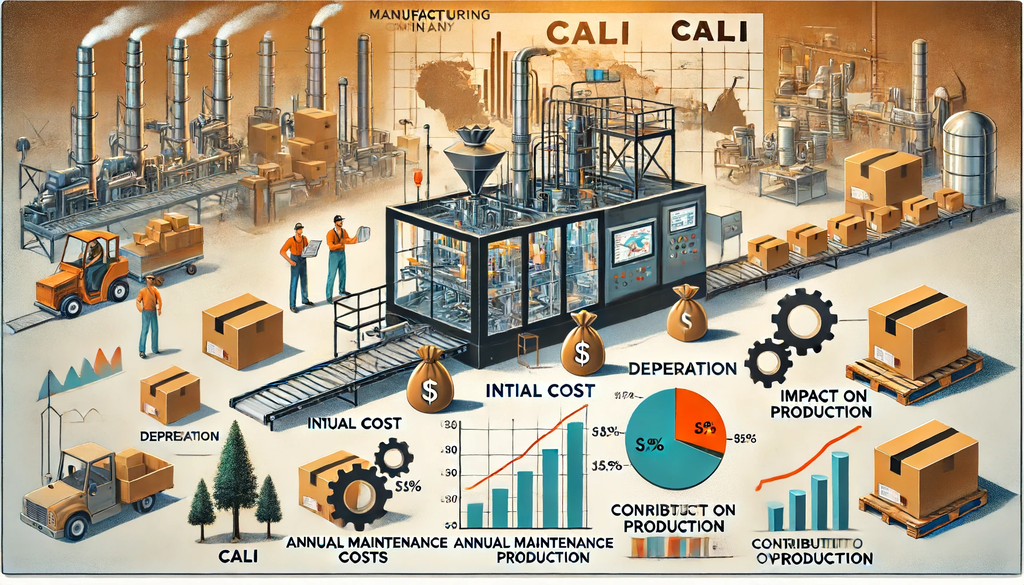

DALL·E 2024-06-17 18.39.12 - A detailed illustration showing a manufacturing company in Cali considering the acquisition of new machinery for making boxes. The central focus is on.webp

## Objetivos

### Objetivo general

Desarrollar e implementar un modelo matemático para evaluar la viabilidad financiera de adquirir maquinaria a largo plazo en una empresa manufacturera.

### Objetivos específicos

- Resolver ecuaciones e inecuaciones de primer grado con una incógnita.
- Interpretar y aplicar los resultados obtenidos en la resolución de ecuaciones e inecuaciones en situaciones problemáticas del mundo real.
- Usar correctamente la notación matemática para expresar la solución de ecuaciones e inecuaciones.

## Trabajando con Python

### Como solucionar ecuaciones de primer grado con Python y la librería sympy

Vamos a solucionar una ecuación de primer grado con Python y la librería sympy. Tomemos el ejemplo de la ecuación

$$3x + 2 = 11.$$

En Python podemos trabajar de forma simbólica para resolver este tipo de ecuaciones. Para ello, primero debemos importar la librería sympy y definir la variable simbólica $x$. Luego, definimos la ecuación y la resolvemos.

```python
from sympy import Symbol, Eq, solve

# Definimos la variable simbólica x como real
x = Symbol('x', real=True)

# Definimos la ecuación

ecuacion = Eq(3*x + 2, 11)

# Resolvemos la ecuación
print("Resolviendo la ecuación")
display(ecuacion)
solucion = solve(ecuacion)

print("la solución de la ecuación es:",solucion)
```

```
Resolviendo la ecuación
```

$\displaystyle 3 x + 2 = 11$

```
la solución de la ecuación es: [3]
```

Note que el programa imprime la solución $[3]$. Esto significa que la solución de la ecuación es $x = 3$.

Observemos otro ejemplo, ahora con la ecuación

$$(x+5)(x-1)=x^2-1.$$

```python
from sympy import Symbol, Eq, solve

# Definimos la variable simbólica x
x = Symbol('x', real=True)

# Definimos la ecuación

ecuacion = Eq((x + 5)*(x-1), x**2-1)

# Resolvemos la ecuación
print("Resolviendo la ecuación")
display(ecuacion)
solucion = solve(ecuacion)

print("la solución de la ecuación es:",solucion)
```

```
Resolviendo la ecuación
```

$\displaystyle \left(x - 1\right) \left(x + 5\right) = x^{2} - 1$

```
la solución de la ecuación es: [1]
```

Note que para la ecuación anterior $x=1$ es solución y esto es porque si se sustituye la solución en la ecuación original, la igualdad se cumple. Sin embargo, si intentamos reescribir la ecuación anterior factorizándola del siguiente modo:
$$(x-1)(x+5)=(x-1)(x+1),$$
se podría pensar que al dividir en ambos lados de la igualdad por $(x-1)$ se obtiene

$$x+5=x+1,$$

lo cual es incorrecto en todos los números reales **¿Por qué?**.

### Como solucionar inecuaciones de primer grado con Python y la librería sympy

Es posible representar la solución de una inecuación gráficamente. Por ejemplo, considere la inecuación:
$$3x+5>2,$$
en la siguiente gráfica se muestra la solución de la inecuación, donde la región sombreada en azul representa la solución de la inecuación.

```python
import libreria3 as li
li.plot_inequality_solution(3,5,2)
```

[figure not shown]

Usando la función anterior podemos gráficar el conjunto de inecuaciones de la forma
$$ax+b>c,$$
por ejemplo la inecuación
$$-3x+5>2,$$

```python
import libreria3 as li
li.plot_inequality_solution(-3,5,2)
```

[figure not shown]

La librería sympy también permite resolver inecuaciones de una forma muy general, para ello debemos ingresar la inecuación en la función solve_univariate_inequality, y este nos devolverá el intervalo de la solución. Por ejemplo, para la inecuación

$$3x+5>2,$$

```python
import sympy as sp

# Definir la variable
x = sp.symbols('x', real=True)

# Definir la inecuación
inequality = 3*x +5> 2

# Resolver la inecuación
solution = sp.solve_univariate_inequality(inequality, x, relational=False)


# Mostrar la solución
print("Solución sin relacional:", solution)
```

[output not shown]

Observe otro ejemplo

$$-3x+5 \leq2,$$

```python
import sympy as sp

# Definir la variable
x = sp.symbols('x', real=True)

# Definir la inecuación
inequality = -3*x+5 <=2

# Resolver la inecuación
solution = sp.solve_univariate_inequality(inequality, x, relational=False)


# Mostrar la solución
print("Solución sin relacional:", solution)
```

[output not shown]

**Note** que la solución de la inecuación anterior es $x\geq1$ y la solución exhibida por el programa es `Interval(1, oo)` lo que significa que la solución incluye el número real 1. Ahora, si se quiere resolver la inecuación

$$-3x+5 <2,$$

usamos el programa

```python
import sympy as sp

# Definir la variable
x = sp.symbols('x', real=True)

# Definir la inecuación
inequality = -3*x+5 <2

# Resolver la inecuación
solution = sp.solve_univariate_inequality(inequality, x, relational=False)


# Mostrar la solución
print("Solución sin relacional:", solution)
```

```
Solución sin relacional: Interval.open(1, oo)
```

se encuentra que la solución es $x>1$ y la solución exhibida por el programa es `Interval.open(1, oo)` lo que significa que la solución no incluye el número real 1.

### Solución de inecuaciones de segundo grado con Python y la librería sympy

Es posible resolver las innecuaciones de segundo grado gráficamente, vamos a ver un ejemplo

$$x^2-3x+2>0,$$

```python
li.plot_inequality_solution2(1,-3,2)
```

[figure not shown]

### Ejercicios de apropiación y aplicación

1. Resuelva las siguientes ecuaciones y explique su solución
   - $3x - 5 = 11$
   - $(3x+2)(x-1)=x^2-1$
   - $\dfrac{x^2-2x+1}{x-1}=3x-6$
   - $\dfrac{x^2-x-6}{x+2}=-1$
2. Resuelva las siguientes inecuaciones y grafique el intervalo de solución
   - $3x+5>2$
   - $-3x+5\leq2$
   - $x^2-2x-3>5x-6$
   - $x^2-2x-3\geq4x +6$

## Conexión con el reto

### Proceso de selección de proveedor de maquinaria

La empresa está considerando la compra de estas máquinas, en la oferta se encontraron con dos proveedores de estas maquinarias. El primer proveedor se llama **Interprase** el cual ofrece un equipo que tiene un costo inicial de $1’000.000 y requiere un mantenimiento anual de $800.000. El segundo proveedor, llamado **Soluciones Express**, ofrece un equipo que tiene un costo inicial significativamente más alto de $8’000.000 y un mantenimiento anual de $110.000.

¿Durante cuánto tiempo se debe utilizar el equipo de **Soluciones Express** para que los costos totales acumulados sean menores que el equipo de **Interprase**, asumiendo que los costos de mantenimiento se mantienen constantes en el tiempo?

Para una decisión más completa, ¿qué otros factores deberían tenerse en cuenta además del costo inicial y el mantenimiento anual?

## Reto

### Análisis de costos de mantenimiento y actualización de software a largo plazo

Una empresa tiene dos equipos cuyos costos de mantenimiento anual aumentan cada año debido al desgaste y otros factores económicos. El costo inicial de mantenimiento del equipo de **Interprase** es de $\$800.000$ y aumenta en $\$20000$ por cada año. De manera similar, el costo inicial de mantenimiento del equipo de **Soluciones Express** es de $\$1'100.000$ y aumenta en un $\$ 400$ por cada año. Además, se espera que el costo de actualización de software para ambas máquinas al inicio sea $\$50.000$ y aumente en una relación $\$2000$ y $\$20$ por tiempo al cuadrado, respectivamente.

1. ¿Al cabo de cuántos años el costo anual de mantenimiento del equipo ofrecido por **Interprase** es igual a 1’200.100?
2. ¿Cómo podemos representar este problema como una inecuación?
3. ¿Durante cuántos años debe usarse el equipo de **Interprase** para que el costo anual de mantenimiento sea menor que el del equipo de **Soluciones Express**?